# Challenge técnico, Thiago Sequeira.

El objetivo del siguiente desafío es demostrar conocimientos básicos sobre Python para el análisis de datos, el entendimiento de un conjunto de datos para poder obtener los insights más relevantes de dicha información y poder identificar las oportunidades claves subyacentes en los datos. Se valorará la resolución de los puntos principalmente poniendo foco la interpretación de los datos y el análisis descriptivo de los mismos.

## Consigna:

El desafío consiste en analizar un conjunto de datos proporcionados (archivo .csv), el cual contiene información de alumnos de la universidad, junto con las principales variables tanto académicas como socio demográficas. De dicho análisis se espera:

- Una notebook desarrollada en Python que cumpla con los siguientes puntos:
  - Funciones básicas sobre los datos:
    - Leer el archivo csv con la librería pandas.
    - Verificar el tipo de dato de cada columna y corregir en caso de ser necesario.
    - Filtrar el conjunto de datos por la modalidad “Distancia”.
    - Tratamiento de datos de alumnos que tengan algún valor faltante (valores nulos). ¿Que se podría hacer con estos casos?
  - Análisis de datos y gráficos:
    - Obtención de los principales estadísticos del conjunto de datos (Pista: Se puede utilizar la librería de pandas, o cualquier similar).
    - Una breve explicación de dichos estadísticos que describa las principales características de los datos.
    - Desarrollar al menos 3 gráficos sobre cualquier variable y dimensión (Se puede utilizar matplotlib, seaborn o cualquier librería gráfica).
    - Explicación de los gráficos anteriores.
    - Desarrollar un gráfico de serie de tiempo (campo de fecha) para describir la forma de pago de los alumnos.

### Funciones basicas sobre los datos:

Importamos las librerias que vamos a utilizar para el desafío. (pandas y matplotlib).

```python
import pandas as pd
from matplotlib import pyplot as plt
```

Hacemos la lectura del csv utilizando pandas y lo definimos en la variable 'df'.

```python
df = pd.read_csv('data_set_challenge - data_set_challenge.csv')
```

```python
df
```

|  | codigo_alumno | codigo_carrera | atr_doc_pago | atr_condicion | carrera_des | periodo | Modalidad | fecha_de_pago | genero | materias_aprobadas | promedio | cantidad_de_pagos |
| --- | --- | --- | --- | --- | --- | --- | --- | --- | --- | --- | --- | --- |
| 0 | 431357998 | 4948 | Facturado | No Aplica | Contador Público | 2014 | Presencial | 2013-11-26 00:00:00.000 | Masculino | 0.0 | 6.80 | 3.0 |
| 1 | 336565855 | 5426 | Facturado | Matricula Paga | Licenciatura En Gestión De Recursos Humanos | 2013 | Distancia | 2013-01-25 00:00:00.000 | Femenino | 0.0 | 7.50 | 1.0 |
| 2 | 348650567 | 5399 | Facturado | Matricula Paga | Abogacía | 2013 | Distancia | 2013-03-12 00:00:00.000 | Masculino | 0.0 | 5.00 | 1.0 |
| 3 | 334403299 | 5388 | Facturado | Matricula Paga | Tecnicatura En Dirección De Protocolo, Organiz... | 2013 | Distancia | 2013-01-18 00:00:00.000 | Femenino | 0.0 | 6.53 | 4.0 |
| 4 | 452032808 | 5399 | Facturado | Matricula Paga | Abogacía | 2014 | Distancia | 2014-02-19 00:00:00.000 | Masculino | 0.0 | 0.00 | 3.0 |
| ... | ... | ... | ... | ... | ... | ... | ... | ... | ... | ... | ... | ... |
| 593250 | 246318825 | 5390 | Facturado | Matricula Paga | Martillero Y Corredor Público | 2012 | Distancia | 2012-04-18 00:00:00.000 | Femenino | 0.0 | 7.50 | 2.0 |
| 593251 | 254735432 | 5403 | No Facturado | Preinscripto | Licenciatura En Comercio Internacional | 2012 | Distancia | 2012-05-07 00:00:00.000 | Masculino | 0.0 | 0.00 | NaN |
| 593252 | 261570695 | 5388 | Facturado | Matricula Paga | Tecnicatura En Dirección De Protocolo, Organiz... | 2012 | Distancia | 2012-05-30 00:00:00.000 | Femenino | 0.0 | 0.00 | 1.0 |
| 593253 | 259831690 | 5426 | Facturado | Matricula Paga | Licenciatura En Gestión De Recursos Humanos | 2012 | Distancia | 2012-05-23 00:00:00.000 | Femenino | 0.0 | 0.00 | 1.0 |
| 593254 | 259831719 | 5399 | Facturado | Matricula Paga | Abogacía | 2012 | Distancia | 2012-06-05 00:00:00.000 | Femenino | 0.0 | 0.00 | 1.0 |

593255 rows × 12 columns

Comenzamos el tratamiento de los valores NULL. Como primera instancia, comenzamos contabilizando cuantos datos nulos tenemos en el dataframe con las sentencias `isnull().sum()`.

```python
df.isnull().sum()
```

```
codigo_alumno              0
codigo_carrera             0
atr_doc_pago               0
atr_condicion              0
carrera_des                0
periodo                    0
Modalidad                  0
fecha_de_pago          20399
genero                  1580
materias_aprobadas         1
promedio                   1
cantidad_de_pagos     211313
dtype: int64
```

Dropeamos las inconsistencias de la columna 'fecha de pago' ya que solo son menos del 3.5% de los datos totales.

```python
df.dropna(subset=['fecha_de_pago'], inplace=True)
```

```python
df
```

|  | codigo_alumno | codigo_carrera | atr_doc_pago | atr_condicion | carrera_des | periodo | Modalidad | fecha_de_pago | genero | materias_aprobadas | promedio | cantidad_de_pagos |
| --- | --- | --- | --- | --- | --- | --- | --- | --- | --- | --- | --- | --- |
| 0 | 431357998 | 4948 | Facturado | No Aplica | Contador Público | 2014 | Presencial | 2013-11-26 00:00:00.000 | Masculino | 0.0 | 6.80 | 3.0 |
| 1 | 336565855 | 5426 | Facturado | Matricula Paga | Licenciatura En Gestión De Recursos Humanos | 2013 | Distancia | 2013-01-25 00:00:00.000 | Femenino | 0.0 | 7.50 | 1.0 |
| 2 | 348650567 | 5399 | Facturado | Matricula Paga | Abogacía | 2013 | Distancia | 2013-03-12 00:00:00.000 | Masculino | 0.0 | 5.00 | 1.0 |
| 3 | 334403299 | 5388 | Facturado | Matricula Paga | Tecnicatura En Dirección De Protocolo, Organiz... | 2013 | Distancia | 2013-01-18 00:00:00.000 | Femenino | 0.0 | 6.53 | 4.0 |
| 4 | 452032808 | 5399 | Facturado | Matricula Paga | Abogacía | 2014 | Distancia | 2014-02-19 00:00:00.000 | Masculino | 0.0 | 0.00 | 3.0 |
| ... | ... | ... | ... | ... | ... | ... | ... | ... | ... | ... | ... | ... |
| 593250 | 246318825 | 5390 | Facturado | Matricula Paga | Martillero Y Corredor Público | 2012 | Distancia | 2012-04-18 00:00:00.000 | Femenino | 0.0 | 7.50 | 2.0 |
| 593251 | 254735432 | 5403 | No Facturado | Preinscripto | Licenciatura En Comercio Internacional | 2012 | Distancia | 2012-05-07 00:00:00.000 | Masculino | 0.0 | 0.00 | NaN |
| 593252 | 261570695 | 5388 | Facturado | Matricula Paga | Tecnicatura En Dirección De Protocolo, Organiz... | 2012 | Distancia | 2012-05-30 00:00:00.000 | Femenino | 0.0 | 0.00 | 1.0 |
| 593253 | 259831690 | 5426 | Facturado | Matricula Paga | Licenciatura En Gestión De Recursos Humanos | 2012 | Distancia | 2012-05-23 00:00:00.000 | Femenino | 0.0 | 0.00 | 1.0 |
| 593254 | 259831719 | 5399 | Facturado | Matricula Paga | Abogacía | 2012 | Distancia | 2012-06-05 00:00:00.000 | Femenino | 0.0 | 0.00 | 1.0 |

572856 rows × 12 columns

Procedo a realizar un histograma para corroborar cual es el dato que más se repite de la columna 'cantidad_de_pagos', para posteriormente hacer la imputación ese mismo valor a los valores nulos.

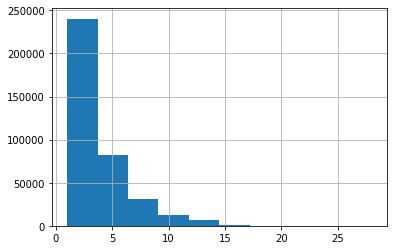

```python
hist = df['cantidad_de_pagos'].hist()
```

```python
df.cantidad_de_pagos = df.cantidad_de_pagos.fillna(df.cantidad_de_pagos.mode()[0])
```

Para los valores de la columna 'genero' realizo la imputación con el dato siguiente de cada celda. Por ejemplo: En la primera celda hay un dato nulo pero en la siguiente hay un dato valido, el dato nulo toma como valor el siguiente dato valido.

Podemos observar la cantidad de datos en el siguiente histograma antes de realizar la imputación.

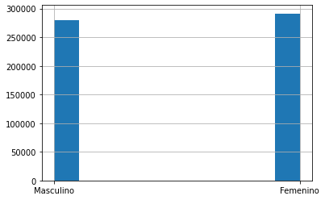

```python
hist = df['genero'].hist()
```

```python
df.genero = df.genero.fillna(method='bfill')
```

Y observamos el mismo histograma pero con la imputación realizada y con los datos actualizados.

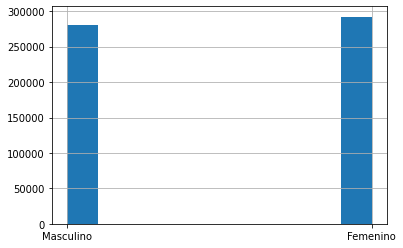

```python
hist = df['genero'].hist()
```

Comprobamos si sigue habiendo existencia de datos nulos con las funciones `.isnull().sum()`.

```python
df.isnull().sum()
```

```
codigo_alumno         0
codigo_carrera        0
atr_doc_pago          0
atr_condicion         0
carrera_des           0
periodo               0
Modalidad             0
fecha_de_pago         0
genero                0
materias_aprobadas    0
promedio              0
cantidad_de_pagos     0
dtype: int64
```

### ¿Que se prodría hacer en casos de tener un valor nulo?

¿Cómo lidiar con los datos faltantes? En nuestro dataFrame hay algunos casos donde no tenemos datos, como por ejemplo en las columnas 'fecha_de_pago', 'cantidad_de_pagos' y 'género'. Obviamente todos estos datos faltantes podrían afectar un análisis de datos o la creación de modelos de aprendizaje de máquina. Por tanto tenemos que lidiar y aplicar técnicas para borrarlos o para completarlos.

Hay diversas maneras de manejar los datos faltantes, como por ejemplo:

- **Dropearlos:** Podemos sacar o eliminar los datos nulos con el método `dropna()`. Se recomienda exclusivamente en casos donde contenemos mucha cantidad de registros válidos, un proceso de limpieza común es quitar cualquier inconsistencia que nos podremos encontrar, ya sea en general o en columnas específicas.
- **Reemplazarlos con valores por defecto:** Podemos definir nuestros valores por defecto dentro de un diccionario, especificamos nombre de la columna y su valor por defecto. Por ejemplo: `valores_por_defecto = {'nombre' : 'DESCONOCIDO', ‘edad’ : 18}`.
- **Reemplazarlos con el promedio:** Podemos llamar al método `mean()` para que automáticamente calcule el promedio de los datos y hacer la imputación con el mismo.
- **Reemplazarlos con la media:** Podemos llamar al método `median()` para que automáticamente calcule la media, que es el valor que está en medio de todos los valores y hacer la imputación con el mismo.
- **Reemplazarlos con el valor más repetido (moda):** La moda es el valor más común que se encuentra en nuestra columna, lo llamamos con el método `mode()`. Hay casos que nuestra moda puede consistir en varias, pueden tener varios valores que empatan. Por ejemplo; pueden haber 50 personas que tengan 22 años y también 50 personas que tengan 45. Ambos serían los números que se repiten más. Por lo tanto tendríamos una serie y nos regresaría un tipo vector de modas. Por tal razon, nosotros tenemos que especificar cual moda queremos que nos regrese, y lo hacemos agregando un 0 entre corchetes al final de tal manera: `df.cantidad_de_pagos = df.cantidad_de_pagos.fillna(df.cantidad_de_pagos.mode()[0])` (agregamos un 0 porque en python el primer numero es 0 y no 1).
- **Reemplazarlos con el valor de la celda siguiente o anterior:** Podemos utilizar los métodos `bfill` para imputar el dato de la celda siguiente o `ffill` de la anterior.

Entre otras técnicas.

Continuamos realizando una limpieza de columnas para mantener todos los titulos en minúscula.

```python
df.columns
```

```
Index(['codigo_alumno', 'codigo_carrera', 'atr_doc_pago', 'atr_condicion',
       'carrera_des', 'periodo', 'Modalidad', 'fecha_de_pago', 'genero',
       'materias_aprobadas', 'promedio', 'cantidad_de_pagos'],
      dtype='object')
```

```python
df.rename(columns = {'Modalidad':'modalidad'}, inplace=True)
```

Observamos que el cambio se realizó con exito.

```python
df
```

|  | codigo_alumno | codigo_carrera | atr_doc_pago | atr_condicion | carrera_des | periodo | modalidad | fecha_de_pago | genero | materias_aprobadas | promedio | cantidad_de_pagos |
| --- | --- | --- | --- | --- | --- | --- | --- | --- | --- | --- | --- | --- |
| 0 | 431357998 | 4948 | Facturado | No Aplica | Contador Público | 2014 | Presencial | 2013-11-26 00:00:00.000 | Masculino | 0.0 | 6.80 | 3.0 |
| 1 | 336565855 | 5426 | Facturado | Matricula Paga | Licenciatura En Gestión De Recursos Humanos | 2013 | Distancia | 2013-01-25 00:00:00.000 | Femenino | 0.0 | 7.50 | 1.0 |
| 2 | 348650567 | 5399 | Facturado | Matricula Paga | Abogacía | 2013 | Distancia | 2013-03-12 00:00:00.000 | Masculino | 0.0 | 5.00 | 1.0 |
| 3 | 334403299 | 5388 | Facturado | Matricula Paga | Tecnicatura En Dirección De Protocolo, Organiz... | 2013 | Distancia | 2013-01-18 00:00:00.000 | Femenino | 0.0 | 6.53 | 4.0 |
| 4 | 452032808 | 5399 | Facturado | Matricula Paga | Abogacía | 2014 | Distancia | 2014-02-19 00:00:00.000 | Masculino | 0.0 | 0.00 | 3.0 |
| ... | ... | ... | ... | ... | ... | ... | ... | ... | ... | ... | ... | ... |
| 593250 | 246318825 | 5390 | Facturado | Matricula Paga | Martillero Y Corredor Público | 2012 | Distancia | 2012-04-18 00:00:00.000 | Femenino | 0.0 | 7.50 | 2.0 |
| 593251 | 254735432 | 5403 | No Facturado | Preinscripto | Licenciatura En Comercio Internacional | 2012 | Distancia | 2012-05-07 00:00:00.000 | Masculino | 0.0 | 0.00 | 1.0 |
| 593252 | 261570695 | 5388 | Facturado | Matricula Paga | Tecnicatura En Dirección De Protocolo, Organiz... | 2012 | Distancia | 2012-05-30 00:00:00.000 | Femenino | 0.0 | 0.00 | 1.0 |
| 593253 | 259831690 | 5426 | Facturado | Matricula Paga | Licenciatura En Gestión De Recursos Humanos | 2012 | Distancia | 2012-05-23 00:00:00.000 | Femenino | 0.0 | 0.00 | 1.0 |
| 593254 | 259831719 | 5399 | Facturado | Matricula Paga | Abogacía | 2012 | Distancia | 2012-06-05 00:00:00.000 | Femenino | 0.0 | 0.00 | 1.0 |

572856 rows × 12 columns

Verificamos el tipo de dato de cada columna y corregimos en caso de ser necesario.

```python
df.dtypes
```

```
codigo_alumno           int64
codigo_carrera          int64
atr_doc_pago           object
atr_condicion          object
carrera_des            object
periodo                 int64
modalidad              object
fecha_de_pago          object
genero                 object
materias_aprobadas    float64
promedio              float64
cantidad_de_pagos     float64
dtype: object
```

Observamos que la columna 'fecha_de_pago' es de tipo object y no datetime, 'codigo_alumno', 'codigo_carrera' y 'periodo' son formato int pero debe de ser string ya que luego no queremos hacer algún tipo de cálculo con estos datos. Por otro lado, 'materias_aprobadas' y 'cantidad_de_pagos' deben ser int, ya que no contienen decimales.

Procedemos a realizar dichos cambios:

Hacemos uso de la sentencia `pd.to_datetime` para realizar el cambio de 'fecha_de_pago'. (Hacemos la mudanza desde la tabla original y no de una copia para no tener errores ni advertencias)

```python
df.fecha_de_pago = pd.to_datetime(df.fecha_de_pago)
```

Hacemos uso de la sentencia `astype()` para realizar el cambio de 'codigo_alumno', 'codigo_carrera' y 'periodo' a str.

```python
df.codigo_alumno = df.codigo_alumno.astype(str)
df.codigo_carrera = df.codigo_carrera.astype(str)
df.periodo = df.periodo.astype(str)
```

También hacemos uso de la sentencia astype() para realizar el cambio de 'materias_aprobadas' y 'cantidad_de_pagos' a int.

```python
df.materias_aprobadas = df.materias_aprobadas.astype(int)
df.cantidad_de_pagos = df.cantidad_de_pagos.astype(int)
```

Observamos que los cambios se realizaron con exito y ahora son de los tipos correspondientes.

```python
df.dtypes
```

```
codigo_alumno                 object
codigo_carrera                object
atr_doc_pago                  object
atr_condicion                 object
carrera_des                   object
periodo                       object
modalidad                     object
fecha_de_pago         datetime64[ns]
genero                        object
materias_aprobadas             int32
promedio                     float64
cantidad_de_pagos              int32
dtype: object
```

Por ultimo, filtramos el conjunto de datos por la modalidad 'Distancia' y lo almacenamos en una variable con su mismo nombre.

```python
distancia = df[df['modalidad'] == 'Distancia']
```

Observamos el dataFrame una vez terminada la preparación, limpieza y filtrado de los datos.

```python
distancia
```

|  | codigo_alumno | codigo_carrera | atr_doc_pago | atr_condicion | carrera_des | periodo | modalidad | fecha_de_pago | genero | materias_aprobadas | promedio | cantidad_de_pagos |
| --- | --- | --- | --- | --- | --- | --- | --- | --- | --- | --- | --- | --- |
| 1 | 336565855 | 5426 | Facturado | Matricula Paga | Licenciatura En Gestión De Recursos Humanos | 2013 | Distancia | 2013-01-25 | Femenino | 0 | 7.50 | 1 |
| 2 | 348650567 | 5399 | Facturado | Matricula Paga | Abogacía | 2013 | Distancia | 2013-03-12 | Masculino | 0 | 5.00 | 1 |
| 3 | 334403299 | 5388 | Facturado | Matricula Paga | Tecnicatura En Dirección De Protocolo, Organiz... | 2013 | Distancia | 2013-01-18 | Femenino | 0 | 6.53 | 4 |
| 4 | 452032808 | 5399 | Facturado | Matricula Paga | Abogacía | 2014 | Distancia | 2014-02-19 | Masculino | 0 | 0.00 | 3 |
| 5 | 336565783 | 5390 | Facturado | Matricula Paga | Martillero Y Corredor Público | 2013 | Distancia | 2013-01-25 | Femenino | 0 | 0.00 | 1 |
| ... | ... | ... | ... | ... | ... | ... | ... | ... | ... | ... | ... | ... |
| 593250 | 246318825 | 5390 | Facturado | Matricula Paga | Martillero Y Corredor Público | 2012 | Distancia | 2012-04-18 | Femenino | 0 | 7.50 | 2 |
| 593251 | 254735432 | 5403 | No Facturado | Preinscripto | Licenciatura En Comercio Internacional | 2012 | Distancia | 2012-05-07 | Masculino | 0 | 0.00 | 1 |
| 593252 | 261570695 | 5388 | Facturado | Matricula Paga | Tecnicatura En Dirección De Protocolo, Organiz... | 2012 | Distancia | 2012-05-30 | Femenino | 0 | 0.00 | 1 |
| 593253 | 259831690 | 5426 | Facturado | Matricula Paga | Licenciatura En Gestión De Recursos Humanos | 2012 | Distancia | 2012-05-23 | Femenino | 0 | 0.00 | 1 |
| 593254 | 259831719 | 5399 | Facturado | Matricula Paga | Abogacía | 2012 | Distancia | 2012-06-05 | Femenino | 0 | 0.00 | 1 |

498688 rows × 12 columns

```python
distancia.dtypes
```

```
codigo_alumno                 object
codigo_carrera                object
atr_doc_pago                  object
atr_condicion                 object
carrera_des                   object
periodo                       object
modalidad                     object
fecha_de_pago         datetime64[ns]
genero                        object
materias_aprobadas             int32
promedio                     float64
cantidad_de_pagos              int32
dtype: object
```

### Análisis de datos y gráficos:

Obtención de los principales estadísticos del conjunto de datos con la función `describe()` de Pandas.

```python
distancia.describe()
```

|  | materias_aprobadas | promedio | cantidad_de_pagos |
| --- | --- | --- | --- |
| count | 498688.000000 | 498688.000000 | 498688.000000 |
| mean | 0.090381 | 3.689840 | 2.386508 |
| std | 0.562269 | 3.617136 | 2.350998 |
| min | 0.000000 | 0.000000 | 1.000000 |
| 25% | 0.000000 | 0.000000 | 1.000000 |
| 50% | 0.000000 | 4.710000 | 1.000000 |
| 75% | 0.000000 | 7.000000 | 3.000000 |
| max | 17.000000 | 601.000000 | 16.000000 |

Utilizamos la función `describe()` de Pandas para que nos regrese los principales estadísticos de nuestro dataFrame. El cual incluye:

**count**: Recuento de datos no nulos.

**mean**: Media de los valores.

**std**: Desviación estándar.

**min**: Valor mínimo.

**25%**: El percentil del 25%.

**50%**: El percentil del 50%.

**75%**: El percentil del 75%.

**max**: Valor máximo.

Desarrollamos al menos 3 gráficos sobre cualquier variable y dimensión (Se puede utilizar matplotlib, seaborn o cualquier librería gráfica).

```python
#plt.bar(distancia['carrera_des'], distancia['materias_aprobadas'])
#plt.show
```

Por la grán magnitud de los datos no puedo graficarlos correctamente con la libreria grafica de matplotlib, ya que los datos son almacenados en memoria y no cuento con la necesaria. Por este motivo procedo a hacer la exportación del dataFrame 'distancia' para realizar los graficos en Power BI. (Adjunto el archivo original .pbix al mail).

Hago la extracción del dataFrame 'distancia' con la función `.to_csv`.

```python
#distancia.to_csv('distancia.csv', index=False)
```

Presentación general del dashboard.

[figure not shown]

- Primer gráfico: Recuento género.

El siguiente grafico muestra cuales son los porcentajes del genero de los alumnos de la institución. Los cuales son conformados por un 51,28% (255,74 mil) del género femenino y un 48,72% (242,95 mil) masculino.

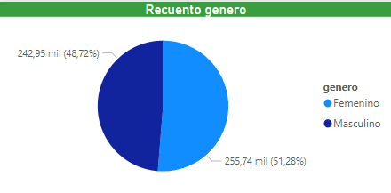

- Segundo gráfico: Promedio general por carrera.

En el siguiente grafico podemos observar el promedio general de las carreras de la institución (discriminado por código de carrera). Donde podemos visualizar la carrera de Escribanía que cuenta con el mejor promedio en calificaciones.

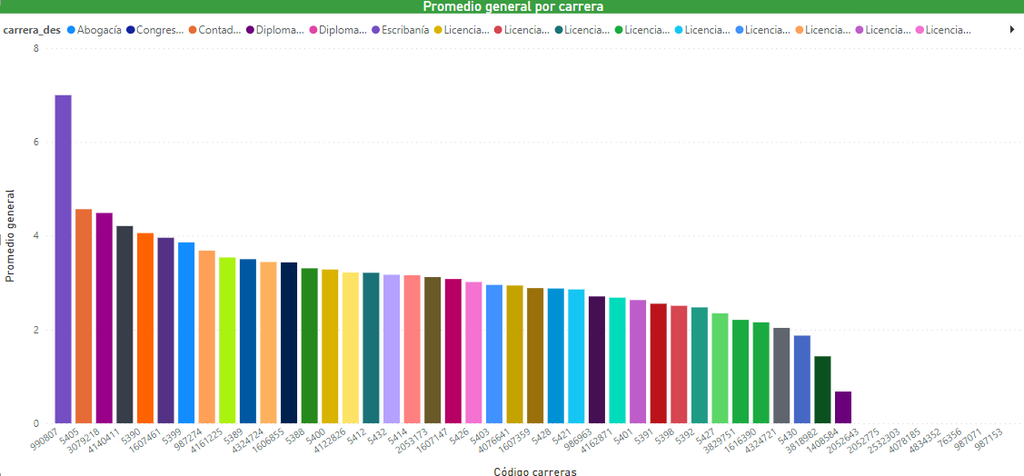

- Tercer gráfico: Recuento de genero por carrera.

En este grafico podemos visualizar la cantidad de alumnos por género de acuerdo a la carrera cursada.

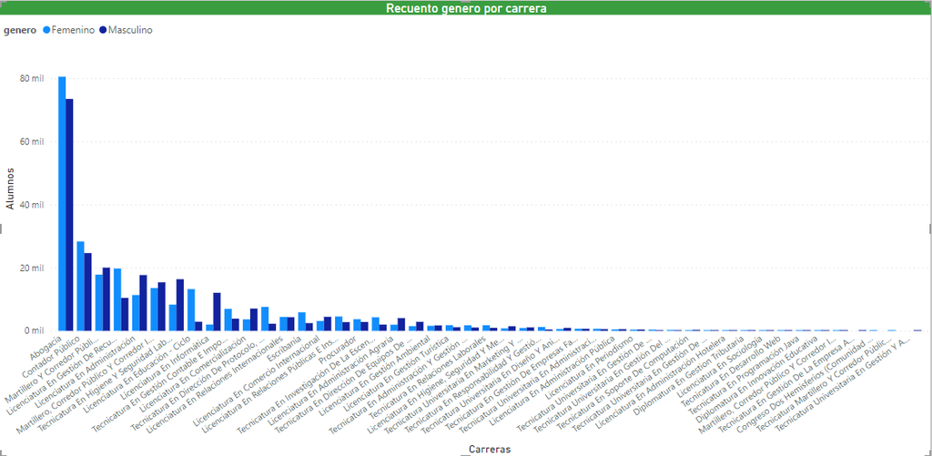

Gráfico de serie de tiempo (campo de fecha) para describir la forma de pago de los alumnos.

En este grafico visualizamos la cantidad de pagos realizados desde 2004 a 2018.

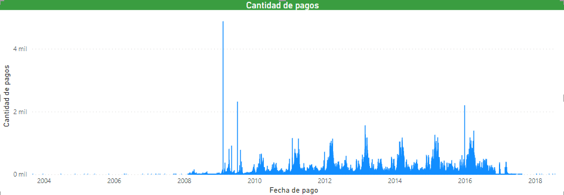